# 9. 向量语义

Natural Language Processing I

9. 向量语义

WU Xiaokun 吴晓堃

xkun.wu [at] gmail

2022/04/15

# 言者所以在意，得意而忘言

## 言与意

> 荃者所以在鱼，得鱼而忘荃  
> 言者所以在意，得意而忘言  
> –《庄子·外物》

## 待会儿去码头整点薯条

> 我们要飞向何方？  
> 我打算待会儿去码头整点薯条。  
> 你误会我了伙计，我说的是咱这一辈子的终极目标：活着是为了什么？  
> 为了待会儿去码头整点薯条。

[figure not shown]

–《待会儿去码头整点薯条》

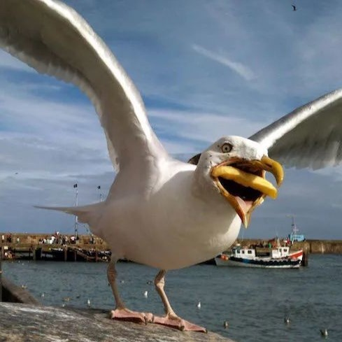

–《去码头整薯条的海鸥》

## 词义与上下文

出现在相似上下文的词通常有相似的词义

- [语言学家, 1950s] **分布假说 distributional hypothesis**
  - [Harris 1954] 词义的区别“大体上与上下文的区别正相关”
- 例如：说“视力测试”时，上下文出现“眼睛”的概率非常高

推论：文本**上下文中词的分布**对词义、语义理解非常重要

- 问题：如何将词转化为可以用来计算的数据表示？

## 向量语义与词嵌入

**词嵌入 embedding**：词义的向量表示

- 来自数学上的“嵌入”，本质上是（不同维数空间的）坐标系变换
- 词与词嵌入是**同一词义的不同表示**
  - 文本中的词：字符串表示
  - 语义空间中的词嵌入：向量表示

> 凡所有相皆是虚妄 – 《金刚经》

**向量语义 vector semantics**：将词转换成语义空间中的等价向量表示

- 在向量空间中可以构造度量：比较词之间的差异
  - 能够**度量差异**，就能研究语义
- 向量表示可以直接用于存储、计算

## 向量表示：独热编码

**独热编码 one-hot encoding**：单有效位编码的向量

- $y = [y_1, y_2, .., y_C]$
- $C$个类；$y_c = 1$表示正确类别是$c$

例如数字$3$的编码：

- $[0, 0, 0, 1, 0, 0, 0, 0, 0, 0]$
- $C = 10, c = 3$

为什么独热编码是很差的语义表示？相似度**差异绝对化**：非0即1

- 无法表示“有点相似”，如“优”、“良”

## 表示学习

回顾“学习”的两种观点：

- 数据观点：寻找对目标任务而言的最佳**数据表示**
- 函数观点：寻找逼近目标任务的最佳**显函数**

NLP强调自动化的**数据表示学习 representation learning**

- 而非人工特征工程，例如one-hot

# 词语义

## 如何表示词义？

到目前为止，讨论的都是字符串、词汇列表索引

- 本质上是**形式化替换**，类似于数理逻辑运算
  - “dog”的含义是`DOG`：$\forall x, DOG(x) \rightarrow MAMMAL(x)$

[Carlson 1977] 语言学家的冷笑话

> Q: What’s the meaning of life?  
> A: LIFE

表示能力非常有限，几乎没有解决任何问题

## 对词义表示有何需求？

讨论表示方法之前，应该先考虑**需求**

**词语义 Lexical Semantics**：对词义的语言学研究

- 词义相近、相反，隐含意义
- 词形变化、多义词、异体字
- 同音字，多音字
- 可以用于推断任务

## 词目与词义

- `mouse`：老鼠；鼠标
- `量`：名词；动词

**词目 lemma**：词典中的不同条目

- 屈折语会涉及到不同**词形 wordform**，例如复数`mice`
- 中文**异体字**：“茴香豆的茴有几种写法？”
  - 茴，回，囘，囬，还有一种是“口”字里面有个“目”字

**词义 word sense**：同一词条的不同含义

- 一词多义非常普遍，对机器理解造成麻烦
  - **上下文**对词义理解至关重要，除非桌子上确实有老鼠

## 同义词

**同义词 synonym**：词义相同或非常接近

```
美丽、漂亮、帅、靓
顽强、顽固
```

- 有可能是性别、感情色彩的区分

**命题 propositional 词义**：形式化定义，替换后不改变句子的真值条件

> 水、$H_2O$
- **形式区别**是语义的一部分
  - $H_2O$一般只用于科学上下文

## 同义？近义？

**对比原理 principle of contrast**：表现形式的改变一定带来含义区别

[Girard 1718] “我不认为任何语言里有同义词”

- 同种语言词义完全相同时：没必要区分词目
- 因此：我们讨论的其实是近义词

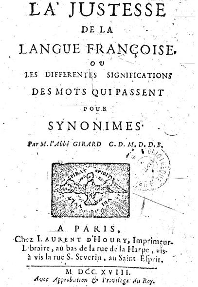

## 间接讨论词义：相似度

**直接**讨论词义的悖论：**词义与表现形式绑定**

- 如果固定表现形式：给不同任务的计算带来困难
- 如果不确定表现形式：没法讨论问题

> 无名天地之始，有名万物之母。–《道德经》

**间接**讨论词义：只关注词（的表现形式）之间的**相似度**

> Q: What is the *universe*?  
> A: Not Nut, but very close.  
> – *Running like Clockwork*
- 为什么“very close”？– *Universe in a Nutshell*
- 相似度可以用于构造**损失函数**
- 对后面**语义**理解任务同样有简化作用

## 如何计算相似度？

最直接的方法是**人工标注**

- 例如：[Hill 2015] SimLex-999 数据集

| vanish | disappear | 9.8 |
| --- | --- | --- |
| belief | impression | 5.95 |
| muscle | bone | 3.65 |
| modest | flexible | 0.98 |
| hole | agreement | 0.3 |

- 可以为机器学习任务提供训练集

缺点：**主观性**带来偏差

## 关联度：语义场

例如：

```
咖啡、茶：相似
茶、杯：相关联
```

**关联度**：经常在同一上下文出现

- 词义上几乎不共享任何特征

**语义场 semantic field**：针对特定领域的词集合，词间共享**结构关系**

- 住房：卧室、厨房、家电

## 关联度：语义框架、角色

**语义框架 semantic frame**：针对特定事件的词集合，词间共享**事件过程**

- 商业交易：买、卖、付款

同一语义框架有不同的**角色 role**

- 商业交易：买方、卖方、商品、金额

鉴别语义框架有助于语法结构分析、机器理解：问答、翻译

```
张三向李四买了一本书。
李四卖给了张三一本书。
```

```
Ich esse Fisch.
Fisch esse Ich.

Fisch isst mich.
mich isst Fisch.
```

## 反义词

**反义词 antonym**：词义只在一个特征维度上相反

```
亮/暗，短/长
```

- 其他特征维度可以非常相似
  - 例如：通常可以充当相同的句子成分

**反向词 reversives**：过程的逆向

```
上/下，涨/汐
```

## 同音字，多音字

中文语音识别任务的难点

同音字

```
这种食物可以zhì’ái。
```

- “致癌”还是“治癌”？

多音字

```
张三还欠款100万。
```

- “hái”还是“huán”？

## 涵义

**涵义 connotation**：情感含义或内涵意义

- 限制讨论：情绪、情感、观点、评价等
- 正面、负面或积极、消极两个维度

情感表达可以很细微

```
仿制、伪造，吸纳、抄袭
```

应用：情感分析、立场识别，商业、政治特殊用语等

## 量化情感维度

[Osgood 1957] 情感词在三个主要（特征）维度上进行区分

- valence：带来的**愉悦程度**
- arousal：激起的**感情强度**
- dominance：施加的**控制级别**

|  | Valence | Arousal | Dominance |
| --- | --- | --- | --- |
| **courageous** | 8.05 | 5.5 | 7.38 |
| **music** | 7.67 | 5.57 | 6.5 |
| **heartbreak** | 2.45 | 5.65 | 3.58 |
| **cub** | 6.71 | 3.95 | 4.24 |

将词表示为空间中的点

- 开创了**向量语义**的建模方法

本质上是**人为指定特征**，即特征工程

# 向量语义

## 语义的计算模型

在讨论了对语义的众多需求之后，我们能实现多少？

- 词义相近、相反，隐含意义
- 词形变化、多义词、异体字
- 同音字，多音字
- 可以用于推断任务

**向量语义 Vector Semantics**：NLP中表示词义的标准方法

## 向量语义的起源

1950s两种观点的融合

- [Osgood 1957] 将词表示为**三维空间中的点**

> [Wittgenstein 1953] “The meaning of a word lies in its use.”
- 词义即其用法的分布，即词或语法的**上下文环境**

> [Harris 1954] “If A and B have almost identical environments we say that they are synonyms.”

## 什么是空心菜？

> 菜无心可活，人无心可不可活？ – 《封神演义》
- 原产東南亞，但目前主要分布于中国长江以南亞热带地区。
  - 我作为北方人，非常好奇这个菜长什么样子

网页搜索得到如下信息：

```
……将空心菜拌上大蒜酱
以绿叶和嫩茎供食用
```

同时，我知道如下信息：

```
蒜香菠菜盖浇饭
甜菜的茎和叶很好吃
```

推断：空心菜是类似菠菜的绿叶蔬菜，茎也可以吃

## 向量语义与表示空间

两种思路的融合

- 将词表示为**多维空间中的点**
- 词义即其用法的分布，即词或语法的**上下文环境**

**向量语义**：将词表示为多维语义空间中的点

- **语义空间**：由词的上下文分布特定决定
- **词嵌入**：语义空间中表示词义的向量

## 词嵌入的可视化

从情感分类任务训练得到的60维空间，投影（t-SNE）到二维平面

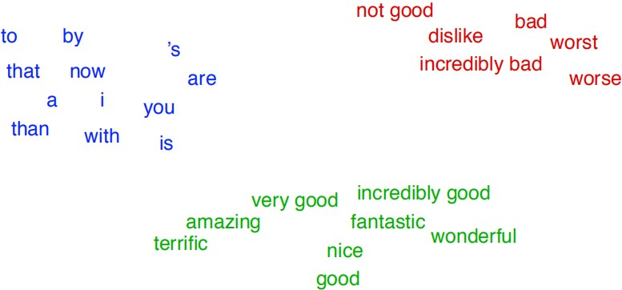

- 词嵌入：语义空间中的点
- 注意三个区域：正面（绿）、负面（红）、中性（蓝）
- 词义相近：在语义空间中相邻

## 向量化表示有何优点？

之前：词的**字符表示**

- 对应的特征：这个词的字符表示是否出现
- 需要**完全一致**的字符串：同时出现在训练集、测试集
  - 问题：很难处理未知词

现代NPL算法全都使用**词嵌入**作为词义的表示形式

- 对应的特征：词嵌入向量中的每个维度
- 可以推广到**相似但未知**的词
  - 比较（嵌入后）两点之间的距离

## 两种常用模型

**tf-idf**

- 信息检索的计算基础；常用作基准模型
- 稀疏表示：上下文中**词计数**的函数

**word2vec**

- 稠密表示：训练**分类器预测**词义相近的可能性

# 词与向量

## 共生矩阵

**共生 co-occurrence 矩阵**：记录词同时出现的频率

- 词嵌入计数的基础工具

两种常用形式

- 词条-文档矩阵：文档内词的分布统计
- 词条-词条矩阵：语料库横向范围内词的分布统计

## 词条-文档矩阵

**词条-文档矩阵 term-document matrix**：每个文档由词的计数向量表示

例如 Shakespeare的四部戏剧

|  | As You Like It | Twelfth Night | Julius Caesar | Henry V |
| --- | --- | --- | --- | --- |
| **battle** | 1 | 0 | 7 | 13 |
| **good** | 114 | 80 | 62 | 89 |
| **fool** | 36 | 58 | 1 | 4 |
| **wit** | 20 | 15 | 2 | 3 |

- 行：词汇表中的词
- 列：文档集合
- 元素值：词在对应文档中的计数

## 文档的向量表示

文档：表示成列向量，每一列对应一个文档，即**文档向量**

|  | As You Like It | Twelfth Night | Julius Caesar | Henry V |
| --- | --- | --- | --- | --- |
| **battle** | 1 | 0 | 7 | 13 |
| **good** | 114 | 80 | 62 | 89 |
| **fool** | 36 | 58 | 1 | 4 |
| **wit** | 20 | 15 | 2 | 3 |

- 文档向量的集合：在**语义向量空间**中
  - 维数：即行数，词汇表中词的数量

## 文档的特征

词：代表文档的一个**特征**

- 数值代表（以当前词度量的）**特征维度上的词义强度**

|  | As You Like It | Twelfth Night | Julius Caesar | Henry V |
| --- | --- | --- | --- | --- |
| **battle** | 1 | 0 | 7 | 13 |
| **good** | 114 | 80 | 62 | 89 |
| **fool** | 36 | 58 | 1 | 4 |
| **wit** | 20 | 15 | 2 | 3 |

文档向量通过（以词度量的）特征描述语义

- 不同特征间数值的相对大小：反映**文档风格**的不同
  - 应用：找出同作者、同类别的文章

## 文档向量的可视化

选取两个比较有代表性的特征

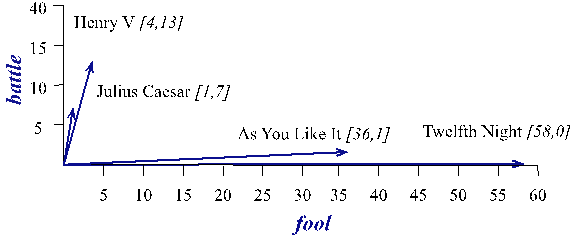

- 很清楚地将文档划分成两个类别：喜剧/悲剧

## 向量表示是信息检索的基础

[Salton 1971] 信息检索的向量空间模型：基于向量表示的**相似度**

|  | As You Like It | Twelfth Night | Julius Caesar | Henry V |
| --- | --- | --- | --- | --- |
| **battle** | 1 | 0 | 7 | 13 |
| **good** | 114 | 80 | 62 | 89 |
| **fool** | 36 | 58 | 1 | 4 |
| **wit** | 20 | 15 | 2 | 3 |

一般情况：相似的列向量代表文档本身相似

- 例如：左边两部喜剧的数值分布较为相似

## 词的向量表示

词：表示成行向量，即**词向量**

- 每个元素代表（以当前文档度量的）**特征维度上的词义强度**

|  | As You Like It | Twelfth Night | Julius Caesar | Henry V |
| --- | --- | --- | --- | --- |
| **battle** | 1 | 0 | 7 | 13 |
| **good** | 114 | 80 | 62 | 89 |
| **fool** | 36 | 58 | 1 | 4 |
| **wit** | 20 | 15 | 2 | 3 |

相似的词行向量代表**词义相似**

- 通常出现在相似的文档中
- 词义：表示成词在文档中的**分布统计**

## 词条-词条矩阵

**词条-词条矩阵 term-term matrix**：列也是词条，即**词向量**的另一形式

- 每个元素代表（以当前词度量的）**特征维度上的词义强度**

[Davies 2015] Wikipedia 语料集

|  | aardvark | … | computer | data | result | pie | sugar | … |
| --- | --- | --- | --- | --- | --- | --- | --- | --- |
| **cherry** | 0 | … | 2 | 8 | 9 | 442 | 25 | … |
| **strawberry** | 0 | … | 0 | 0 | 1 | 60 | 19 | … |
| **digital** | 0 | … | 1670 | 1683 | 85 | 5 | 4 | … |
| **information** | 0 | … | 3325 | 3982 | 378 | 5 | 13 | … |

- 列：代表**上下文**中的词
- 元素值：词条对**同时出现**的计数

## 上下文窗口

上下文可以是文档，但更常用**很小的上下文范围**

- 统计的是局部范围词之间的相关性
- 例如：前后各4个词，称为**上下文窗口**

|  | aardvark | … | computer | data | result | pie | sugar | … |
| --- | --- | --- | --- | --- | --- | --- | --- | --- |
| **cherry** | 0 | … | 2 | 8 | 9 | 442 | 25 | … |
| **strawberry** | 0 | … | 0 | 0 | 1 | 60 | 19 | … |
| **digital** | 0 | … | 1670 | 1683 | 85 | 5 | 4 | … |
| **information** | 0 | … | 3325 | 3982 | 378 | 5 | 13 | … |

- 一定是**对称**矩阵
- 相似的行/列向量：词义相似

## 词向量的可视化

反过来也成立：选取两个关联度高的词，向量也比较相似

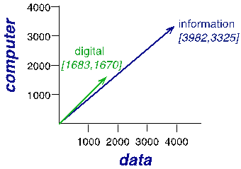

问题：如何**度量**向量间相似性？

# 余弦相似度

## 内积与度量

内积是**内积空间的标准度量**

$$\textbf{v} \cdot \textbf{w} = \sum_i v_i w_i = v_1 w_1 + v_2 w_2 + \dots$$

向量的内积是标量：

- 数值大时：向量在同方向上重合较大
- 最小值0：向量正交

## 绝对数值的问题

内积作为度量：更长的向量数值也更大

$$|\textbf{v}| = \sqrt{\sum_i v_i^2}$$

**频率**更高的词：对应的向量更长

- 例如词条-词条计数：有些词（“的”等停用词）更有可能与其他词出现在一起
- 这与理想度量相矛盾：度量应该反映对象的**内在特性**
  - 内在特性不随外在表现而变化，故度量应该是频率无关的
- 解决方法：应该对长度做**归一化**

## cosine 相似度

对向量长度做**归一化**

$$\begin{aligned}
\cos \theta &= \frac{\textbf{v} \cdot \textbf{w}}{|\textbf{v}| |\textbf{w}|}\\
&= \frac{\sum_i v_i w_i}{\sqrt{\sum_i v_i^2} \sqrt{\sum_i w_i^2}}
\end{aligned}$$

- 单位化向量：长度为$1$
  - 频率计数非负：取值范围是$[0,1]$

很明显，这就是**余弦定理**

$$\begin{aligned}
\textbf{v} \cdot \textbf{w} &= |\textbf{v}| |\textbf{w}| \cos \theta\\
\end{aligned}$$

## cosine 相似度：示例

|  | pie | data | computer |
| --- | --- | --- | --- |
| **cherry** | 442 | 8 | 2 |
| **digital** | 5 | 1683 | 1670 |
| **information** | 5 | 3982 | 3325 |

$$\begin{aligned}
\cos \theta &= \frac{\sum_i v_i w_i}{\sqrt{\sum_i v_i^2} \sqrt{\sum_i w_i^2}}
\end{aligned}$$

- $\cos (\text{cherry, information}) = .017$
- $\cos (\text{digital, information}) = .996$

由相似度：很容易区分两组词间的**词义差距**

## cosine 相似度：可视化

同样，已知两组词间的词义差距作为**先验知识**

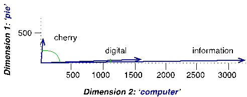

- 由图中向量夹角：很容易验证相似度

# TF-IDF

## 简单计数的问题

共生矩阵中的元素代表**词频**：相对文档、上下文

- 回忆Zipf定律：绝大多数高频词没有实意
  - `the, it, 了，的`
- 并且原始词频**辨识度**不强
  - 例如：`good`甚至可以涵盖中性、负面态度
    - 考核非常难的任务时，“好”可以认为是“勉强通过”

**词频悖论**

- 上下文中高频词远比低频词重要
- 但**频率过高**的词反倒不重要：所有上下文都出现

解决方法：需要**给词频加权**的合理方法

## 加权词频

**TF-IDF**：通常用于文档维度

$$w_{t,d} = \text{tf}_{t,d} \times \text{idf}_t$$

- 减少**无辨识度**的高频词权重

**Pointwise Mutual Information (PMI)**：通常用于词维度

$$\text{PMI}(w,c) = \log_2 \frac{P(w,c)}{P(w)P(c)}$$

- 解决的问题：上下文中的词是不是**出现**的？例如“蝴蝶”
  - 计算思路：与**先验期望值**对比

## 词条频率 tf

之前使用文档中词条的简单计数

$$\text{tf}_{t,d} \propto \Gamma(t,d)$$

[Luhn 1957] 修正后，按**对数“挤压”**数值

$$\text{tf}_{t,d} = \log_{10} (\Gamma(t,d) +1)$$

- “挤压”：重要性随着词频增加而减小
  - 不能认为“好”x100次的文档比“好”x1次重要100倍
- 加一：防止词频为零时计算对数

## 文档频率 df

$\text{df}_t$：词条$t$出现过的**文档数量**

- 区别：出现过的总数

例如 Shakespeare 的 37 部戏剧

|  | 总数 | df |
| --- | --- | --- |
| **Romeo** | 113 | 1 |
| **action** | 113 | 31 |

- “Romeo”是非常有**辨识度**的词：只有一部出现过

## 逆文档频率 idf

idf的意义：给$\text{df}_t$较低的词赋予更高的权重

$$\text{idf}_{t} \propto \frac{1}{\text{df}_t}$$

- $\text{df}_t$较低：**辨识度**高，能够帮助区分文档
- 反之，所有文档都出现的词并不重要

定义：文档总数$N$ vs 文档频率$\text{df}_t$

$$\text{idf}_{t} = \log_{10} (\frac{N}{\text{df}_t})$$

- 同样按对数“挤压”数值

## 逆文档频率 idf：示例

idf的意义：给$\text{df}_t$较低的词赋予更高的权重

$$\text{idf}_{t} \propto \frac{1}{\text{df}_t}$$

- $\text{df}_t$较低：**辨识度**高，能够帮助区分文档
- 反之，所有文档都出现的词并不重要

定义：文档总数$N$ vs 文档频率$\text{df}_t$

$$\text{idf}_{t} = \log_{10} (\frac{N}{\text{df}_t})$$

- 同样按对数“挤压”数值

| 词 | df | idf |
| --- | --- | --- |
| Romeo | 1 | 1.57 |
| salad | 2 | 1.27 |
| Falstaff | 4 | 0.967 |
| forest | 12 | 0.489 |
| battle | 21 | 0.246 |
| wit | 34 | 0.037 |
| fool | 36 | 0.012 |
| good | 37 | 0 |
| sweet | 37 | 0 |

## 什么是文档？

通常意义的文档

- Shakespeare 的戏剧集
- 《资治通鉴》294卷

但文档可以是**任何语料**

- 跟任务有关，比如将一卷书按自然段拆分

## tf-idf 定义

tf与idf的乘积

$$w_{t,d} = \text{tf}_{t,d} \times \text{idf}_t$$

|  | As You Like It | Twelfth Night | Julius Caesar | Henry V |
| --- | --- | --- | --- | --- |
| **battle** | 0.074 | 0 | 0.22 | 0.28 |
| **good** | 0 | 0 | 0 | 0 |
| **fool** | 0.019 | 0.021 | 0.0036 | 0.0083 |
| **wit** | 0.049 | 0.044 | 0.018 | 0.022 |

- “good”出现在所有文档：不重要

# 逐点互信息

## 加权词频的两个维度

**TF-IDF**：通常用于文档维度

- 使用词条-文档矩阵计算

逐点互信息 **Pointwise mutual information (PMI)**：通常用于词维度

- 使用词条-词条矩阵计算
- 解决的问题：上下文中的词是不是**出现**的？例如“蝴蝶”
  - 计算思路：与**先验期望值**对比

## PMI 定义

如何描述“偶然（同时）出现”？例如“上课”、“下雨”

- 数学上：独立事件、同时发生

[Fano 1961, Church 1989] 目标词$w$、上下文词$c$

$$\text{PMI}(w,c) = \log_2 \frac{P(w,c)}{P(w)P(c)}$$

- 分子：**同时观测**到两个词的可能性
- 分母：两个**独立事件同时发生**的概率
  - 等于两个事件概率的乘积

## PMI （不）适用场景

趋向正无穷：用于找出**关联性强**的词

$$\text{PMI}(w,c) = \log_2 \frac{P(w,c)}{P(w)P(c)}$$

趋向负无穷：极度不相关？通常**不可靠**

- 例如：单独出现的概率是$10^{-6}$
  - 只有共同出现的概率小于$10^{-12}$，才能确定两个词不相关
  - 这个数量级需要非常大的语料集才能计算、训练
- 更严重：一般来说**人也很难判断**两个词到底有多“不相关”

因此，通常只讨论**非负区间**取值

## 非负PMI

**非负 Positive PMI (PPMI)**：将PMI数值截取在非负区间

$$\text{PPMI}(w,c) = \max( \log_2 \frac{P(w,c)}{P(w)P(c)}, 0)$$

给定词条-词条矩阵$F \in \mathbb{R}^{W \times C}$

$$p_{ij} = \frac{f_{ij}}{\sum_{i=1}^W \sum_{j=1}^C f_{ij}},
p_{i*} = \frac{\sum_{j=1}^C f_{ij}}{\sum_{i=1}^W \sum_{j=1}^C f_{ij}},
p_{*j} = \frac{\sum_{i=1}^W f_{ij}}{\sum_{i=1}^W \sum_{j=1}^C f_{ij}}$$

$$\text{PPMI}_{ij} = \text{PPMI}(w_i,c_j) = \max( \log_2 \frac{p_{ij}}{p_{i*}p_{*j}}, 0)$$

## PPMI：示例 I

|  | computer | data | result | pie | sugar | $\Gamma(w)$ |
| --- | --- | --- | --- | --- | --- | --- |
| **cherry** | 2 | 8 | 9 | 442 | 25 | 486 |
| **strawberry** | 0 | 0 | 1 | 60 | 19 | 80 |
| **digital** | 1670 | 1683 | 85 | 5 | 4 | 3447 |
| **information** | 3325 | 3982 | 378 | 5 | 13 | 7703 |
| $\Gamma(c)$ | 4997 | 5673 | 473 | 512 | 61 | 11716 |

- $P(w=\text{information}, c=\text{data}) = \frac{3982}{11716} = .3399$
- $P(w=\text{information}) = \frac{7703}{11716} = .6575$
- $P(c=\text{data}) = \frac{5673}{11716} = .4842$
- $PPMI(\text{information}, \text{data}) = \log_2(.3399/(.6575 \times .4842)) = .0944$

## PPMI：示例 II

|  | computer | data | result | pie | sugar |
| --- | --- | --- | --- | --- | --- |
| **cherry** | 0 | 0 | 0 | 4.38 | 3.30 |
| **strawberry** | 0 | 0 | 0 | 4.10 | 5.51 |
| **digital** | 0.18 | 0.01 | 0 | 0 | 0 |
| **information** | 0.02 | 0.09 | 0.28 | 0 | 0 |

- cherry, strawberry 与 pie, sugar 非常相关
- data 与 information 轻度相关

## PPMI 与罕见词

PPMI的问题：**低频词**的PMI值非常高

$$\text{PMI}(w,c) = \log_2 \frac{P(w,c)}{P(w)P(c)}$$

解决办法：**幂函数修正**上下文词的概率

$$\begin{aligned}
\text{PPMI}_\alpha(w,c) &= \max( \log_2 \frac{P(w,c)}{P(w)P_\alpha(c)}, 0)\\
P_\alpha(c) &= \frac{\Gamma(c)^\alpha}{\sum_c \Gamma(c)^\alpha}
\end{aligned}$$

- [Levy 2015] $\alpha = 0.75$时，可以改善很多任务的计算性能
  - $P(c) \ll 1, \alpha < 1 \Rightarrow P_\alpha(c) > P(c)$
  - 例如：$P(a) = .99, P(b) = .01 \Rightarrow P_\alpha(a) = .97, P_\alpha(b) = .03$

# 向量模型的应用

## 回顾：向量语法

向量语法模型将词表示为向量，向量中的元素是**加权后的计数**

- 词条-文档：文档集；TF-IDF
- 词条-词条：上下文窗口；PPMI

向量通常是稀疏的

**TF-IDF模型**、**PPMI模型**

- 相似度：余弦值

## 文档相似度

TF-IDF模型通常用于确定**文档之间**的相似度

- 将文档表示成所有词向量的**重心**：$d=\frac{\sum_i^k w_i}{k}$
- 使用余弦相似度比较文档：$\cos(d_1,d_2)$

应用：信息检索，抄袭检测，推荐系统等

## 词相似度

TF-IDF模型和PPMI模型都可以用于比较**词之间**的相似度

应用：查找同义段落，跟踪词义变化，自动发现未知词义等

# Review

## 本章内容

向量语义、词嵌入。词义需求。向量化词义。余弦相似度。TF-IDF模型、PPMI模型。

**重点**：向量语义、词嵌入；向量表示、上下文分布；共生矩阵（词条-文档矩阵、词条-词条矩阵）；余弦相似度；TF-IDF模型、PPMI模型。

**难点**：向量表示、上下文分布的优点。

## 学习目标

- 理解词、词嵌入都是词义的表现形式。
- 理解间接讨论语义的原因（形、义不绑定）、方法（相似度）。
- 理解语言学对语义的需求。
- 理解向量语义是两种观点的融合：向量表示、上下文分布。
- 理解向量表示的优点：便于计算、压缩信息、容易处理未知词。
- 理解上下文分布的优点：通过相似度间接讨论词义。
- 理解共生矩阵的两种常用形式（词条-文档矩阵、词条-词条矩阵），及其用法（行、列代表词义）。
- 理解余弦相似度。
- 理解TF-IDF模型的构造方法（统计词条-文档频数）、解决的问题（降低高频词的重要性）。
- 理解PPMI模型的构造方法（统计词条-词条频数）、解决的问题（判断是否偶然同时出现）。

## 问题

简述启发向量语义的两种观点，及其（间接讨论词义的）优点。

简述向量语义、词嵌入的含义。

简述共生矩阵的两种常用形式，及其用法。

简述TF-IDF模型、PPMI模型的构造方法、解决的问题。